# Stock Market, License & Unemployment Rate Final Project

- Minyue Wu: 12147190
- Jingjing Zhang 12149103

```python
%matplotlib inline
%config InlineBackend.figure_format = 'retina'
import matplotlib.pyplot as plt
import numpy as np

import requests, json

import pandas as pd
import seaborn as sns
sns.set_style("whitegrid", rc={'axes.linewidth': 2.5})
sns.set_context('notebook', font_scale=1.45, rc={"lines.linewidth": 3, "figure.figsize" : (7, 3)})

import pytz
import datetime

from urllib.parse import quote

from scipy import stats
import statsmodels.api as sm
import statsmodels.formula.api as smf
import statsmodels.regression.mixed_linear_model as sm_mlm

from time import sleep
import dask.dataframe as dd
```

# 15 Years Anlysis

We went through stock market data, license application data, and unemployment data for the recent 15 years to do analysis

## Variations in the Stock Market

```python
from googlefinance.client import get_price_data, get_prices_data, get_prices_time_data
get_price_data({"q" : ".DJI", "i" : "86400", "x" : "INDEXDJX", 'p': "15Y"}).head()
```

|  | Open | High | Low | Close | Volume |
| --- | --- | --- | --- | --- | --- |
| 2002-11-29 15:00:00 | 8933.67 | 8950.33 | 8891.29 | 8896.09 | 109703600 |
| 2002-12-02 15:00:00 | 8902.95 | 9043.37 | 8787.15 | 8862.57 | 282094700 |
| 2002-12-03 15:00:00 | 8861.13 | 8861.13 | 8721.88 | 8742.93 | 240678900 |
| 2002-12-04 15:00:00 | 8734.22 | 8811.62 | 8653.38 | 8737.85 | 283217200 |
| 2002-12-05 15:00:00 | 8740.66 | 8769.05 | 8608.75 | 8623.28 | 241334100 |

```python
finance = get_price_data({"q" : ".DJI", "i" : "86400", "x" : "INDEXDJX", 'p': "15Y"})
```

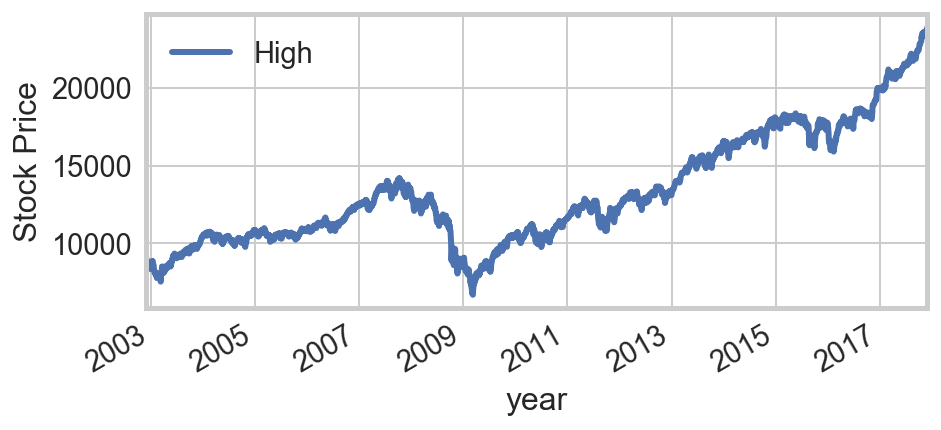

```python
ax = finance.plot(y = "High")
ax.set_xlabel("year")
ax.set_ylabel("Stock Price")
```

```
Text(0,0.5,'Stock Price')
```

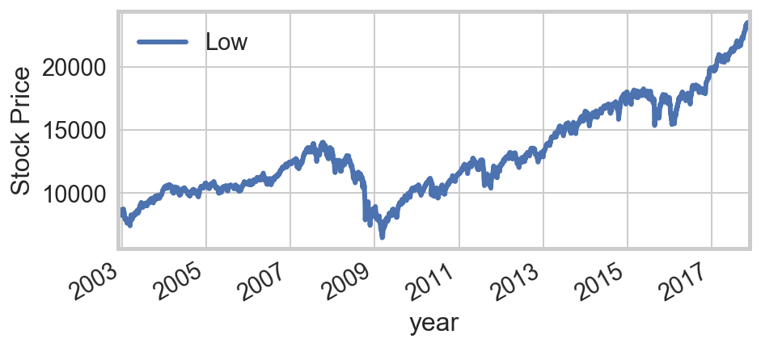

```python
ax = finance.plot(y = "Low")
ax.set_xlabel("year")
ax.set_ylabel("Stock Price")
```

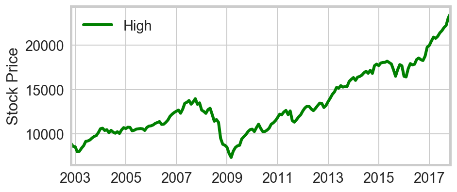

```python
ax = finance.resample("1M").mean().plot(c= "g", y = "High")
ax.set_xlabel("")
ax.set_ylabel("Stock Price");
```

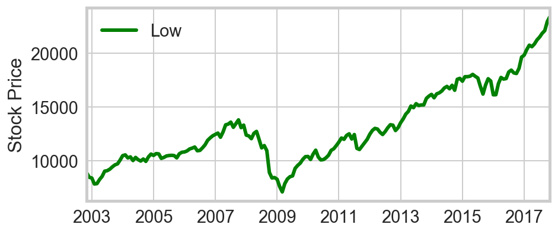

```python
ax = finance.resample("1M").mean().plot(c= "g", y = "Low")
ax.set_xlabel("")
ax.set_ylabel("Stock Price");
```

- We save the finance data to csv file to be prepared to merge the data later

```python
finance.to_csv('finance.csv')
```

```python
finance = pd.read_csv ('finance.csv')
```

```python
finance.head()
```

|  | Date | Open | High | Low | Close | Volume |
| --- | --- | --- | --- | --- | --- | --- |
| 0 | 11/29/2002 | 8933.67 | 8950.33 | 8891.29 | 8896.09 | 109703600 |
| 1 | 12/2/2002 | 8902.95 | 9043.37 | 8787.15 | 8862.57 | 282094700 |
| 2 | 12/3/2002 | 8861.13 | 8861.13 | 8721.88 | 8742.93 | 240678900 |
| 3 | 12/4/2002 | 8734.22 | 8811.62 | 8653.38 | 8737.85 | 283217200 |
| 4 | 12/5/2002 | 8740.66 | 8769.05 | 8608.75 | 8623.28 | 241334100 |

```python
finance.max()
```

```
Date       9/9/2016
Open        23597.2
High        23638.9
Low         23551.6
Close       23590.8
Volume    738442453
dtype: object
```

```python
finance.min()
```

```
Date      1/10/2003
Open              0
High        6709.61
Low         6469.95
Close       6547.05
Volume            0
dtype: object
```

## Business Licenses Data Analysis

```python
html = "https://data.cityofchicago.org/Community-Economic-Development/Business-Licenses/r5kz-chrr"
license = pd.read_csv("Business_Licenses.csv", usecols = ["APPLICATION CREATED DATE", "BUSINESS ACTIVITY", "APPLICATION TYPE"],low_memory = False)
license.dropna(inplace = True)
license.head(5)
```

|  | BUSINESS ACTIVITY | APPLICATION TYPE | APPLICATION CREATED DATE |
| --- | --- | --- | --- |
| 5 | Home Repair Services (Home Occ) | ISSUE | 8/30/16 |
| 7 | Organizer of Vendors That Sell for Retail at a... | ISSUE | 8/30/16 |
| 11 | Retail Sales of General Merchandise | ISSUE | 8/29/16 |
| 12 | Sale of Food Prepared Onsite Without Dining Area | C_LOC | 8/4/16 |
| 24 | Provide Waxing Services \| Skincare Services | ISSUE | 8/30/16 |

- Save the data to csv file to be prepared for merge the data

```python
license.to_csv('license.csv')
```

```python
license.head()
```

[output not shown]

```python
license = pd.read_csv('license.csv')
```

- Clean the data, change the name for the column to be prepared for merge later

```python
license = license.rename(columns={'APPLICATION CREATED DATE':'Date'})
```

```python
license.head()
```

|  | Unnamed: 0 | BUSINESS ACTIVITY | APPLICATION TYPE | Date |
| --- | --- | --- | --- | --- |
| 0 | 0 | Home Repair Services (Home Occ) | ISSUE | 8/30/2016 |
| 1 | 1 | Organizer of Vendors That Sell for Retail at a... | ISSUE | 8/30/2016 |
| 2 | 2 | Retail Sales of General Merchandise | ISSUE | 8/29/2016 |
| 3 | 3 | Sale of Food Prepared Onsite Without Dining Area | C_LOC | 8/4/2016 |
| 4 | 4 | Provide Waxing Services \| Skincare Services | ISSUE | 8/30/2016 |

### Detail analysis of year 2017, 2013, 2011, 2006, 2003

- We pick five years randomly to do a detail analysis of the number of business applications each year

```python
year17 = license['Date'].str.contains('2017')
year13 = license['Date'].str.contains('2013')
year11 = license['Date'].str.contains('2011')
year06 = license['Date'].str.contains('2006')
year03 = license['Date'].str.contains('2003')
```

### 2017 Analysis:

- Total number of business application: 8551
- Total number of license issued in 2017: 7998
- Total number of license renewed in 2017: 1

```python
year_2017 = license[year17]
year_2017.count()
```

```
Unnamed: 0           8551
BUSINESS ACTIVITY    8551
APPLICATION TYPE     8551
Date                 8551
dtype: int64
```

```python
issue17 = year_2017['APPLICATION TYPE'].str.contains('ISSUE')
issue_2017 = year_2017[issue17]
sum_issue_17 = issue_2017.count()['APPLICATION TYPE']
print(sum_issue_17)
```

```
7998
```

```python
renew17 = year_2017['APPLICATION TYPE'].str.contains('RENEW')
renew_2017 = year_2017[renew17]
sum_renew_17 = renew_2017.count()['APPLICATION TYPE']
print(sum_renew_17)
```

```
1
```

- Top five business License types issued in 2017

```python
BA17 = issue_2017['BUSINESS ACTIVITY'].value_counts()
BA17.head(5)
```

```
Markets / Promotes Pharmaceuticals to Health Care Professionals and Conducts Business for More than 15 Calendar Days per Year    1314
5 Day Single - Special Event Food                                                                                                 482
Preparation of Food and Dining on Premise With Seating                                                                            314
Peddler- Retail Sales of General Merchandise, Whole Uncut Fruits/Vegetables, Flowers, Moving Along the Public Way                 291
Sale of Food Prepared Onsite With Dining Area                                                                                     200
Name: BUSINESS ACTIVITY, dtype: int64
```

### 2013 Analysis:

- Total number of business application: 9139
- Total number of license issued: 8628
- Total number of license renewed: 0

```python
year_2013 = license[year13]
year_2013.count()
```

```
Unnamed: 0           9139
BUSINESS ACTIVITY    9139
APPLICATION TYPE     9139
Date                 9139
dtype: int64
```

```python
issue13 = year_2013['APPLICATION TYPE'].str.contains('ISSUE')
issue_2013 = year_2013[issue13]
sum_issue_13 = issue_2013.count()['APPLICATION TYPE']
print(sum_issue_13)
```

```
8628
```

```python
renew13 = year_2013['APPLICATION TYPE'].str.contains('RENEW')
renew_2013 = year_2013[renew13]
sum_renew_13 = renew_2013.count()['APPLICATION TYPE']
print(sum_renew_13)
```

```
0
```

- Top five business License types issued in 2013

```python
BA13 = issue_2013['BUSINESS ACTIVITY'].value_counts()
BA13.head(5)
```

```
Special Event Food                                                                                                   1235
Preparation of Food and Dining on Premise With Seating                                                                546
Peddler- Retail Sales of General Merchandise, Whole Uncut Fruits/Vegetables, Flowers, Moving Along the Public Way     443
Retail Sales of General Merchandise                                                                                   322
Street Performer, Moving Along the Public Way                                                                         272
Name: BUSINESS ACTIVITY, dtype: int64
```

### 2011 Analysis:

- Total number of business application: 3498
- Total number of license issued: 3367
- Total number of license renewed: 0

```python
year_2011 = license[year11]
year_2011.count()
```

```
Unnamed: 0           3498
BUSINESS ACTIVITY    3498
APPLICATION TYPE     3498
Date                 3498
dtype: int64
```

```python
issue11 = year_2011['APPLICATION TYPE'].str.contains('ISSUE')
issue_2011 = year_2011[issue11]
sum_issue_11 = issue_2011.count()['APPLICATION TYPE']
print(sum_issue_11)
```

```
3367
```

```python
renew11 = year_2011['APPLICATION TYPE'].str.contains('RENEW')
renew_2011 = year_2011[renew11]
sum_renew_11 = renew_2011.count()['APPLICATION TYPE']
print(sum_renew_11)
```

```
0
```

- Top five business License types issued in 2011

```python
BA11 = issue_2011['BUSINESS ACTIVITY'].value_counts()
BA11.head(5)
```

```
Special Event Food                   1082
Retail Sales of Perishable Foods     1066
Retail Sale of Tobacco                266
Special Event Beer & Wine             226
Consumption of Liquor on Premises     156
Name: BUSINESS ACTIVITY, dtype: int64
```

### 2006 Analysis:

- Total number of business application: 2876
- Total number of license issued: 2760
- Total number of license renewed: 0

```python
year_2006 = license[year06]
year_2006.count()
```

```
Unnamed: 0           2876
BUSINESS ACTIVITY    2876
APPLICATION TYPE     2876
Date                 2876
dtype: int64
```

```python
issue06 = year_2006['APPLICATION TYPE'].str.contains('ISSUE')
issue_2006 = year_2006[issue06]
sum_issue_06 = issue_2006.count()['APPLICATION TYPE']
print(sum_issue_06)
```

```
2760
```

```python
renew06 = year_2006['APPLICATION TYPE'].str.contains('RENEW')
renew_2006 = year_2006[renew06]
sum_renew_06 = renew_2006.count()['APPLICATION TYPE']
print(sum_renew_06)
```

```
0
```

- Top five business License types issued in 2006

```python
BA06 = issue_2006['BUSINESS ACTIVITY'].value_counts()
BA06.head(5)
```

```
Retail Sales of Perishable Foods                                            1506
Retail Sale of Tobacco                                                       454
Consumption of Liquor on Premises                                            164
Retail Sales of Packaged Liquor                                               97
Provide Parking Spaces For a Fee -Available and Advertised to the Public      81
Name: BUSINESS ACTIVITY, dtype: int64
```

### 2003 Analysis:

- Total number of business application: 11279
- Total number of license issued: 3036
- Total number of license renewed: 8134

```python
year_2003 = license[year03]
year_2003.count()
```

```
Unnamed: 0           11279
BUSINESS ACTIVITY    11279
APPLICATION TYPE     11279
Date                 11279
dtype: int64
```

```python
issue03 = year_2003['APPLICATION TYPE'].str.contains('ISSUE')
issue_2003 = year_2003[issue03]
sum_issue_03 = issue_2003.count()['APPLICATION TYPE']
print(sum_issue_03)
```

```
3036
```

```python
renew03 = year_2003['APPLICATION TYPE'].str.contains('RENEW')
renew_2003 = year_2003[renew03]
sum_renew_03 = renew_2003.count()['APPLICATION TYPE']
print(sum_renew_03)
```

```
8134
```

- Top five business License types issued in 2003

```python
BA03 = issue_2003['BUSINESS ACTIVITY'].value_counts()
BA03.head(5)
```

```
Retail Sales of Perishable Foods                            1697
Retail Sale of Tobacco                                       586
Consumption of Liquor on Premises                            171
Operation of a Fuel Filling Station                           82
Not-For-Profit Selling Raffles for Prizes of $50 or More      79
Name: BUSINESS ACTIVITY, dtype: int64
```

## Merge the License and Finance data

- Save the merged data to csv file
- New data analysis

```python
result = pd.merge(license, finance, how='right', on=['Date', 'Date'])
```

```python
result.head(5)
```

|  | Unnamed: 0 | BUSINESS ACTIVITY | APPLICATION TYPE | Date | Open | High | Low | Close | Volume |
| --- | --- | --- | --- | --- | --- | --- | --- | --- | --- |
| 0 | 0.0 | Home Repair Services (Home Occ) | ISSUE | 8/30/2016 | 18491.28 | 18514.29 | 18408.52 | 18454.3 | 68916111 |
| 1 | 1.0 | Organizer of Vendors That Sell for Retail at a... | ISSUE | 8/30/2016 | 18491.28 | 18514.29 | 18408.52 | 18454.3 | 68916111 |
| 2 | 4.0 | Provide Waxing Services \| Skincare Services | ISSUE | 8/30/2016 | 18491.28 | 18514.29 | 18408.52 | 18454.3 | 68916111 |
| 3 | 5.0 | Heating, Ventilation and Air Conditioning Serv... | ISSUE | 8/30/2016 | 18491.28 | 18514.29 | 18408.52 | 18454.3 | 68916111 |
| 4 | 7.0 | Laundry Service - Drop Off Only | ISSUE | 8/30/2016 | 18491.28 | 18514.29 | 18408.52 | 18454.3 | 68916111 |

```python
test=result.dropna()
```

```python
test.head()
```

|  | Unnamed: 0 | BUSINESS ACTIVITY | APPLICATION TYPE | Date | Open | High | Low | Close | Volume |
| --- | --- | --- | --- | --- | --- | --- | --- | --- | --- |
| 0 | 0.0 | Home Repair Services (Home Occ) | ISSUE | 8/30/2016 | 18491.28 | 18514.29 | 18408.52 | 18454.3 | 68916111 |
| 1 | 1.0 | Organizer of Vendors That Sell for Retail at a... | ISSUE | 8/30/2016 | 18491.28 | 18514.29 | 18408.52 | 18454.3 | 68916111 |
| 2 | 4.0 | Provide Waxing Services \| Skincare Services | ISSUE | 8/30/2016 | 18491.28 | 18514.29 | 18408.52 | 18454.3 | 68916111 |
| 3 | 5.0 | Heating, Ventilation and Air Conditioning Serv... | ISSUE | 8/30/2016 | 18491.28 | 18514.29 | 18408.52 | 18454.3 | 68916111 |
| 4 | 7.0 | Laundry Service - Drop Off Only | ISSUE | 8/30/2016 | 18491.28 | 18514.29 | 18408.52 | 18454.3 | 68916111 |

```python
test.to_csv('merge_l_f.csv')
```

```python
merge1 = pd.read_csv('merge_l_f.csv')
```

- The summary of daily application

```python
daily_count = license['Date'].value_counts()
daily_count.head()
```

```
3/27/2002    8500
3/25/2003    8151
9/24/2002    5028
10/3/2001     445
4/28/2016     182
Name: Date, dtype: int64
```

```python
daily_count.head()
```

```
3/27/2002    8500
3/25/2003    8151
9/24/2002    5028
10/3/2001     445
4/28/2016     182
Name: Date, dtype: int64
```

- We count the daily count and save it as a seperate csv file, to be prepared to be merged with the stock price data, to analyze the relationship betweent the stock price each day and the amount of daily license application

```python
daily_count.to_csv('DCOUNT')
```

```python
daily_count = pd.read_csv('DCOUNT.csv')
```

```python
column = ["Date","COUNT"]
daily_count.columns = column
```

```python
daily_count.head()
```

|  | Date | COUNT |
| --- | --- | --- |
| 0 | 3/25/2003 | 8151 |
| 1 | 9/24/2002 | 5028 |
| 2 | 10/3/2001 | 445 |
| 3 | 4/28/2016 | 182 |
| 4 | 4/27/2016 | 174 |

## Umemployment data analysis

```python
unemployment = pd.read_csv('unemployment.csv')
```

```python
unemployment.head()
```

|  | Date | Chicago |
| --- | --- | --- |
| 0 | 1/1/1990 | 8.8 |
| 1 | 2/1/1990 | 8.7 |
| 2 | 3/1/1990 | 8.6 |
| 3 | 4/1/1990 | 8.9 |
| 4 | 5/1/1990 | 8.6 |

### Plot of umemployment rate of ALL years

- Max unemployment rate: 12.6%, 1/1/2010
- Lowest unemployment rate: 4.5%, 10/1/2006

```
Text(0,0.5,'unemployment rate')
```

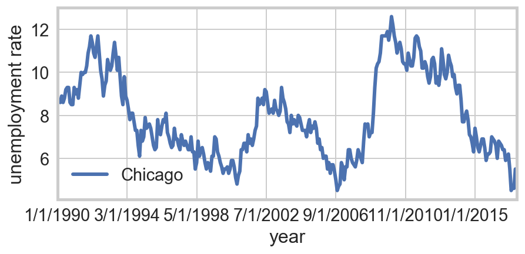

```python
un = unemployment.plot(y = "Chicago", x = "Date")
un.set_xlabel("year")
un.set_ylabel("unemployment rate")
```

```python
unemployment.loc[unemployment['Chicago'].idxmax()]
```

```
Date       1/1/2010
Chicago        12.6
Name: 240, dtype: object
```

```python
unemployment.loc[unemployment['Chicago'].idxmin()]
```

```
Date       10/1/2006
Chicago          4.5
Name: 201, dtype: object
```

### Analyze the past FIFTEEN years unemployment rate

We see fifteen years and all year share the same unemployment rate but with different dates

- Max unemployment rate: 12.6%, 1/1/2010
- Lowest unemployment rate: 4.5%, 10/1/2006

```python
fifteenyear = unemployment['Date'].str.contains('2017')+unemployment['Date'].str.contains('2016')+unemployment['Date'].str.contains('2015')+unemployment['Date'].str.contains('2014')+unemployment['Date'].str.contains('2013')+unemployment['Date'].str.contains('2012')+unemployment['Date'].str.contains('2011')+unemployment['Date'].str.contains('2010')+unemployment['Date'].str.contains('2009')+unemployment['Date'].str.contains('2008')+unemployment['Date'].str.contains('2007')+unemployment['Date'].str.contains('2006')+unemployment['Date'].str.contains('2005')+unemployment['Date'].str.contains('2004')+unemployment['Date'].str.contains('2003')
```

```python
fifteen_year = unemployment[fifteenyear]
```

```python
fifteen_year.loc[fifteen_year['Chicago'].idxmax()]
```

```
Date       1/1/2010
Chicago        12.6
Name: 240, dtype: object
```

```python
fifteen_year.loc[fifteen_year['Chicago'].idxmin()]
```

```
Date       10/1/2006
Chicago          4.5
Name: 201, dtype: object
```

## Merge number of license application and stock market data

- We will analyze the data to see if the numbe rof license application have any relationship with stock market price

```python
result2 = pd.merge(daily_count, finance, how='right', on=['Date', 'Date'])
```

```python
result2.head(5)
```

|  | Date | COUNT | Open | High | Low | Close | Volume |
| --- | --- | --- | --- | --- | --- | --- | --- |
| 0 | 3/25/2003 | 8151.0 | 8216.85 | 8337.72 | 8180.72 | 8280.23 | 258045400 |
| 1 | 4/28/2016 | 182.0 | 18023.88 | 18035.73 | 17796.55 | 17830.76 | 100898966 |
| 2 | 4/27/2016 | 174.0 | 17996.14 | 18084.66 | 17920.26 | 18041.55 | 109073815 |
| 3 | 6/19/2014 | 103.0 | 16909.90 | 16923.43 | 16858.88 | 16921.46 | 80221250 |
| 4 | 7/28/2017 | 95.0 | 21787.51 | 21841.18 | 21756.12 | 21830.31 | 285634661 |

```python
test2 = result2.dropna()
```

```python
test2.head()
```

|  | Date | COUNT | Open | High | Low | Close | Volume |
| --- | --- | --- | --- | --- | --- | --- | --- |
| 0 | 3/25/2003 | 8151.0 | 8216.85 | 8337.72 | 8180.72 | 8280.23 | 258045400 |
| 1 | 4/28/2016 | 182.0 | 18023.88 | 18035.73 | 17796.55 | 17830.76 | 100898966 |
| 2 | 4/27/2016 | 174.0 | 17996.14 | 18084.66 | 17920.26 | 18041.55 | 109073815 |
| 3 | 6/19/2014 | 103.0 | 16909.90 | 16923.43 | 16858.88 | 16921.46 | 80221250 |
| 4 | 7/28/2017 | 95.0 | 21787.51 | 21841.18 | 21756.12 | 21830.31 | 285634661 |

```python
test2.to_csv('merge_regress1.csv')
```

### We run OLS regression on the merged license data and stock market data

#### Fifteen years high stock market price have significant relationship with license application

We see the p-value=0.008, and t-value=2.659, therefore we conlude there is significant relationship between Business license application and High stock price. As the stock market price goes up, the license application number goes up by 0.0016 high price. As this coefficient is very low and there is an extreme outlier, the relationship is not obvious when look at the plot

```python
ols = smf.ols(formula = "COUNT ~ High",
              data = test2)
model = ols.fit()
model.summary()
```

OLS Regression Results

| Dep. Variable: | COUNT | R-squared: | 0.002 |
| --- | --- | --- | --- |
| Model: | OLS | Adj. R-squared: | 0.002 |
| Method: | Least Squares | F-statistic: | 7.072 |
| Date: | Wed, 29 Nov 2017 | Prob (F-statistic): | 0.00786 |
| Time: | 17:55:34 | Log-Likelihood: | -23364. |
| No. Observations: | 3697 | AIC: | 4.673e+04 |
| Df Residuals: | 3695 | BIC: | 4.674e+04 |
| Df Model: | 1 |  |  |
| Covariance Type: | nonrobust |  |  |

|  | coef | std err | t | P>\|t\| | [0.025 | 0.975] |
| --- | --- | --- | --- | --- | --- | --- |
| Intercept | 1.1666 | 8.439 | 0.138 | 0.890 | -15.379 | 17.712 |
| High | 0.0016 | 0.001 | 2.659 | 0.008 | 0.000 | 0.003 |

| Omnibus: | 12491.372 | Durbin-Watson: | 0.957 |
| --- | --- | --- | --- |
| Prob(Omnibus): | 0.000 | Jarque-Bera (JB): | 2031550974.613 |
| Skew: | 60.008 | Prob(JB): | 0.00 |
| Kurtosis: | 3632.589 | Cond. No. | 5.24e+04 |

#### Fifteen years Low stock market price have significant relationship with license application

```python
ols = smf.ols(formula = "COUNT ~ Low",
              data = test2)
model = ols.fit()
model.summary()
```

OLS Regression Results

| Dep. Variable: | COUNT | R-squared: | 0.002 |
| --- | --- | --- | --- |
| Model: | OLS | Adj. R-squared: | 0.002 |
| Method: | Least Squares | F-statistic: | 7.041 |
| Date: | Wed, 29 Nov 2017 | Prob (F-statistic): | 0.00800 |
| Time: | 17:55:18 | Log-Likelihood: | -23364. |
| No. Observations: | 3697 | AIC: | 4.673e+04 |
| Df Residuals: | 3695 | BIC: | 4.674e+04 |
| Df Model: | 1 |  |  |
| Covariance Type: | nonrobust |  |  |

|  | coef | std err | t | P>\|t\| | [0.025 | 0.975] |
| --- | --- | --- | --- | --- | --- | --- |
| Intercept | 1.4822 | 8.342 | 0.178 | 0.859 | -14.872 | 17.837 |
| Low | 0.0016 | 0.001 | 2.654 | 0.008 | 0.000 | 0.003 |

| Omnibus: | 12491.300 | Durbin-Watson: | 0.957 |
| --- | --- | --- | --- |
| Prob(Omnibus): | 0.000 | Jarque-Bera (JB): | 2031460071.692 |
| Skew: | 60.007 | Prob(JB): | 0.00 |
| Kurtosis: | 3632.508 | Cond. No. | 5.13e+04 |

#### We plot the regression line with count as dependent value, High and Low volumn as independent value

Plot stock market HIGH price and the number of license application relationship

- The plot does not show an obvious relationship between the number of license application and the high stock price. One reason is that there is an outlier too faraway, the other reason is that the coefficient is small

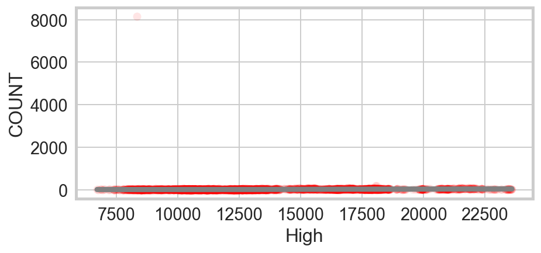

```python
m = pd.Series(name = "COUNT", data = model.resid + test2["High"] * model.params["High"])
sns.regplot(x = test2["High"], y = m, lowess = True,
            scatter_kws = {"alpha" : 0.1, "color" : "red"}, line_kws = {"color" : "grey"});
```

Plot stock market LOW price and the number of license application relationship

- The plot does not show an obvious relationship between the number of license application and the low stock price. One reason is that there is an outlier too faraway, the other reason is that the coefficient is small

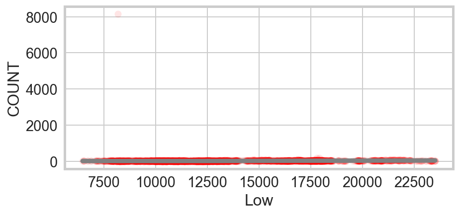

```python
n = pd.Series(name = "COUNT", data = model.resid + test2["Low"] * model.params["Low"])
sns.regplot(x = test2["Low"], y = n, lowess = True,
            scatter_kws = {"alpha" : 0.1, "color" : "red"}, line_kws = {"color" : "grey"});
```

#### We used Seaborn to double check the graphs to ensure the accuracy

- We saw these two graphs are exactly same, so we conclude that the stock market price and the business license data has significant relationship, but the relationship is not obvious

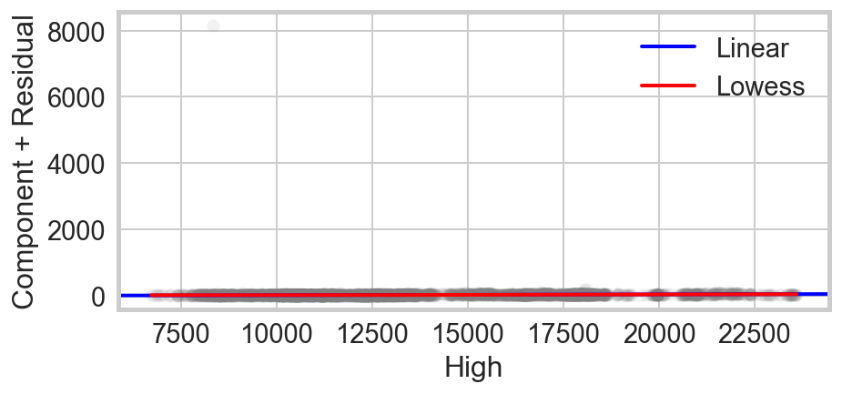

```python
f = pd.Series(name = "Component + Residual", data = model.resid + test2["High"] * model.params["High"])
ax = sns.regplot(x = test2["High"], y = f, scatter = True, fit_reg = False,
            scatter_kws = {"alpha" : 0.1, "color" : "grey"})
sns.regplot(x = test2["High"], y = f, scatter = False,
            lowess = False, robust = True, label = "Linear",
            scatter_kws = {"alpha" : 0.1, "color" : "grey"}, line_kws = {"color" : "blue", "linewidth" : 2})
sns.regplot(x = test2["High"], y = f, scatter = False,
            lowess = True, label = "Lowess",
            scatter_kws = {"alpha" : 0}, line_kws = {"color" : "red", "linewidth" : 2}, ax = ax);

ax.legend()
```

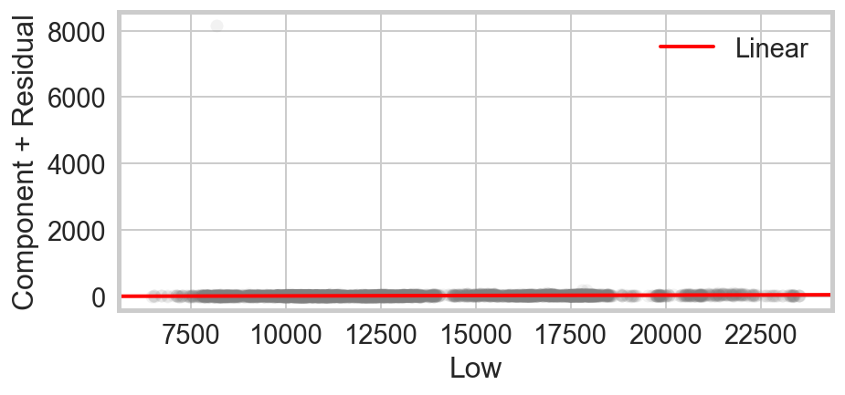

```python
f = pd.Series(name = "Component + Residual", data = model.resid + test2["Low"] * model.params["Low"])
ax2 = sns.regplot(x = test2["Low"], y = f, scatter = True, fit_reg = False,
            scatter_kws = {"alpha" : 0.1, "color" : "grey"})
sns.regplot(x = test2["Low"], y = f, scatter = False,
            lowess = False, robust = True, label = "Linear",
            scatter_kws = {"alpha" : 0.1, "color" : "grey"}, line_kws = {"color" : "red", "linewidth" : 2})
sns.regplot(x = test2["Low"], y = f, scatter = False,
            lowess = True, label = "Lowess",
            scatter_kws = {"alpha" : 0}, line_kws = {"color" : "blue", "linewidth" : 2}, ax = ax);

ax2.legend()
```

### Merge all there data sets together (Unemployment, Stock Price, & License data merge)

- Find out the relationship between unemployment rate and stock price
- Also find the relationship between unemployment rate and number of license application

```python
result3 = pd.merge(unemployment, test2, how='right', on=['Date', 'Date'])
```

```python
result3.head()
```

|  | Date | Chicago | COUNT | Open | High | Low | Close | Volume |
| --- | --- | --- | --- | --- | --- | --- | --- | --- |
| 0 | 4/1/2003 | 8.0 | 15.0 | 7992.83 | 8100.53 | 7979.69 | 8069.86 | 263594500 |
| 1 | 5/1/2003 | 8.2 | 18.0 | 8478.48 | 8488.35 | 8340.23 | 8454.25 | 198576000 |
| 2 | 7/1/2003 | 8.8 | 17.0 | 8983.66 | 9050.82 | 8871.20 | 9040.95 | 230462300 |
| 3 | 8/1/2003 | 8.6 | 11.0 | 9232.68 | 9234.22 | 9138.29 | 9153.97 | 212647600 |
| 4 | 10/1/2003 | 7.7 | 10.0 | 9276.80 | 9472.76 | 9276.80 | 9469.20 | 237109200 |

```python
test3 = result3.dropna()
```

```python
test3.head()
```

|  | Date | Chicago | COUNT | Open | High | Low | Close | Volume |
| --- | --- | --- | --- | --- | --- | --- | --- | --- |
| 0 | 4/1/2003 | 8.0 | 15.0 | 7992.83 | 8100.53 | 7979.69 | 8069.86 | 263594500 |
| 1 | 5/1/2003 | 8.2 | 18.0 | 8478.48 | 8488.35 | 8340.23 | 8454.25 | 198576000 |
| 2 | 7/1/2003 | 8.8 | 17.0 | 8983.66 | 9050.82 | 8871.20 | 9040.95 | 230462300 |
| 3 | 8/1/2003 | 8.6 | 11.0 | 9232.68 | 9234.22 | 9138.29 | 9153.97 | 212647600 |
| 4 | 10/1/2003 | 7.7 | 10.0 | 9276.80 | 9472.76 | 9276.80 | 9469.20 | 237109200 |

```python
test3.to_csv('merge_regress2.csv')
```

#### We run regression between Unemployment rate and the Stock Market Price to see the relationship

```python
ols = smf.ols(formula = "Chicago ~ High",
              data = test3)
model = ols.fit()
model.summary()
```

OLS Regression Results

| Dep. Variable: | Chicago | R-squared: | 0.163 |
| --- | --- | --- | --- |
| Model: | OLS | Adj. R-squared: | 0.155 |
| Method: | Least Squares | F-statistic: | 20.83 |
| Date: | Wed, 29 Nov 2017 | Prob (F-statistic): | 1.35e-05 |
| Time: | 17:01:17 | Log-Likelihood: | -228.10 |
| No. Observations: | 109 | AIC: | 460.2 |
| Df Residuals: | 107 | BIC: | 465.6 |
| Df Model: | 1 |  |  |
| Covariance Type: | nonrobust |  |  |

|  | coef | std err | t | P>\|t\| | [0.025 | 0.975] |
| --- | --- | --- | --- | --- | --- | --- |
| Intercept | 11.5484 | 0.783 | 14.742 | 0.000 | 9.995 | 13.101 |
| High | -0.0003 | 5.81e-05 | -4.564 | 0.000 | -0.000 | -0.000 |

| Omnibus: | 33.616 | Durbin-Watson: | 0.078 |
| --- | --- | --- | --- |
| Prob(Omnibus): | 0.000 | Jarque-Bera (JB): | 6.408 |
| Skew: | 0.098 | Prob(JB): | 0.0406 |
| Kurtosis: | 1.828 | Cond. No. | 5.57e+04 |

```python
ols = smf.ols(formula = "Chicago ~ Low",
              data = test3)
model = ols.fit()
model.summary()
```

OLS Regression Results

| Dep. Variable: | Chicago | R-squared: | 0.165 |
| --- | --- | --- | --- |
| Model: | OLS | Adj. R-squared: | 0.157 |
| Method: | Least Squares | F-statistic: | 21.11 |
| Date: | Wed, 29 Nov 2017 | Prob (F-statistic): | 1.19e-05 |
| Time: | 17:01:35 | Log-Likelihood: | -227.98 |
| No. Observations: | 109 | AIC: | 460.0 |
| Df Residuals: | 107 | BIC: | 465.3 |
| Df Model: | 1 |  |  |
| Covariance Type: | nonrobust |  |  |

|  | coef | std err | t | P>\|t\| | [0.025 | 0.975] |
| --- | --- | --- | --- | --- | --- | --- |
| Intercept | 11.5207 | 0.772 | 14.915 | 0.000 | 9.989 | 13.052 |
| Low | -0.0003 | 5.8e-05 | -4.595 | 0.000 | -0.000 | -0.000 |

| Omnibus: | 34.580 | Durbin-Watson: | 0.081 |
| --- | --- | --- | --- |
| Prob(Omnibus): | 0.000 | Jarque-Bera (JB): | 6.471 |
| Skew: | 0.097 | Prob(JB): | 0.0393 |
| Kurtosis: | 1.822 | Cond. No. | 5.43e+04 |

#### We run regression between Unemployment rate and the number of license application to see the relationship

- We found no significant relationship between unemployment rate and license application because of the large P-value and small t-value
- We also observed the R-squared is a very small number, very little variable is explained by this regression model

```python
ols = smf.ols(formula = "Chicago ~ COUNT",
              data = test3)
model = ols.fit()
model.summary()
```

OLS Regression Results

| Dep. Variable: | Chicago | R-squared: | 0.032 |
| --- | --- | --- | --- |
| Model: | OLS | Adj. R-squared: | 0.023 |
| Method: | Least Squares | F-statistic: | 3.509 |
| Date: | Wed, 29 Nov 2017 | Prob (F-statistic): | 0.0638 |
| Time: | 16:34:28 | Log-Likelihood: | -236.03 |
| No. Observations: | 109 | AIC: | 476.1 |
| Df Residuals: | 107 | BIC: | 481.5 |
| Df Model: | 1 |  |  |
| Covariance Type: | nonrobust |  |  |

|  | coef | std err | t | P>\|t\| | [0.025 | 0.975] |
| --- | --- | --- | --- | --- | --- | --- |
| Intercept | 8.5933 | 0.342 | 25.151 | 0.000 | 7.916 | 9.271 |
| COUNT | -0.0266 | 0.014 | -1.873 | 0.064 | -0.055 | 0.002 |

| Omnibus: | 32.663 | Durbin-Watson: | 0.110 |
| --- | --- | --- | --- |
| Prob(Omnibus): | 0.000 | Jarque-Bera (JB): | 7.034 |
| Skew: | 0.226 | Prob(JB): | 0.0297 |
| Kurtosis: | 1.840 | Cond. No. | 40.4 |

#### We run regression on all three datasets: Unemployment rate & Stock Market Price & number of license application. We got the same result as the anlaysis above.

#### We found there is significant relationship between unemployment and stock market price, but there is no relationship between unemployment and license application.

- while holding the number of license application fixed, we see the p-value for the high price is 0.000, also we see the t-value is -4.195. So we conclude there is significant negative relationship between unemployment rate and high stock market price, because of the small P-value and large t-value
- while holding high stock market price fixed, we see the p-value for the number of license application is 0.358, also we see the t-value is 0.922. So we conclude no significant relationship between unemployment rate and number of license application, because of the large P-value and small t-value
- We also observed the R-squared is a very small number, very little variable is explained by this regression model

```python
ols = smf.ols(formula = "Chicago ~ High + COUNT",
              data = test3)
model = ols.fit()
model.summary()
```

OLS Regression Results

| Dep. Variable: | Chicago | R-squared: | 0.170 |
| --- | --- | --- | --- |
| Model: | OLS | Adj. R-squared: | 0.154 |
| Method: | Least Squares | F-statistic: | 10.82 |
| Date: | Wed, 29 Nov 2017 | Prob (F-statistic): | 5.28e-05 |
| Time: | 17:34:00 | Log-Likelihood: | -227.66 |
| No. Observations: | 109 | AIC: | 461.3 |
| Df Residuals: | 106 | BIC: | 469.4 |
| Df Model: | 2 |  |  |
| Covariance Type: | nonrobust |  |  |

|  | coef | std err | t | P>\|t\| | [0.025 | 0.975] |
| --- | --- | --- | --- | --- | --- | --- |
| Intercept | 11.7835 | 0.824 | 14.295 | 0.000 | 10.149 | 13.418 |
| High | -0.0003 | 7.29e-05 | -4.195 | 0.000 | -0.000 | -0.000 |
| COUNT | 0.0152 | 0.017 | 0.922 | 0.358 | -0.018 | 0.048 |

| Omnibus: | 35.118 | Durbin-Watson: | 0.085 |
| --- | --- | --- | --- |
| Prob(Omnibus): | 0.000 | Jarque-Bera (JB): | 6.627 |
| Skew: | 0.129 | Prob(JB): | 0.0364 |
| Kurtosis: | 1.820 | Cond. No. | 5.85e+04 |

```python
ols = smf.ols(formula = "Chicago ~ Low + COUNT",
              data = test3)
model = ols.fit()
model.summary()
```

OLS Regression Results

| Dep. Variable: | Chicago | R-squared: | 0.172 |
| --- | --- | --- | --- |
| Model: | OLS | Adj. R-squared: | 0.156 |
| Method: | Least Squares | F-statistic: | 11.01 |
| Date: | Wed, 29 Nov 2017 | Prob (F-statistic): | 4.53e-05 |
| Time: | 17:38:16 | Log-Likelihood: | -227.51 |
| No. Observations: | 109 | AIC: | 461.0 |
| Df Residuals: | 106 | BIC: | 469.1 |
| Df Model: | 2 |  |  |
| Covariance Type: | nonrobust |  |  |

|  | coef | std err | t | P>\|t\| | [0.025 | 0.975] |
| --- | --- | --- | --- | --- | --- | --- |
| Intercept | 11.7599 | 0.812 | 14.483 | 0.000 | 10.150 | 13.370 |
| Low | -0.0003 | 7.29e-05 | -4.237 | 0.000 | -0.000 | -0.000 |
| COUNT | 0.0159 | 0.017 | 0.959 | 0.340 | -0.017 | 0.049 |

| Omnibus: | 36.143 | Durbin-Watson: | 0.090 |
| --- | --- | --- | --- |
| Prob(Omnibus): | 0.000 | Jarque-Bera (JB): | 6.698 |
| Skew: | 0.130 | Prob(JB): | 0.0351 |
| Kurtosis: | 1.814 | Cond. No. | 5.70e+04 |

#### We plot the relationship between unemployment and license application

- We firstly plot the regression with pandas, and then check with Seaborn.
- We found these two graphs are the same, from the shape of the line we conclude there is no significant relationship between Unemployment and the license application

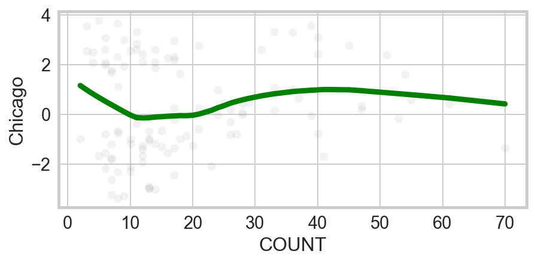

```python
m = pd.Series(name = "Chicago", data = model.resid + test3["COUNT"] * model.params["COUNT"])
sns.regplot(x = test3["COUNT"], y = m, lowess = True,
            scatter_kws = {"alpha" : 0.1, "color" : "grey"}, line_kws = {"color" : "green"});
```

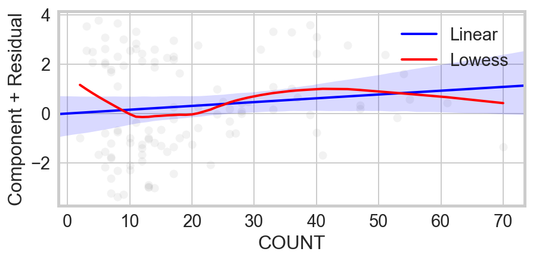

```python
f = pd.Series(name = "Component + Residual", data = model.resid + test3["COUNT"] * model.params["COUNT"])
ax = sns.regplot(x = test3["COUNT"], y = f, scatter = True, fit_reg = False,
            scatter_kws = {"alpha" : 0.1, "color" : "grey"})
sns.regplot(x = test3["COUNT"], y = f, scatter = False,
            lowess = False, robust = True, label = "Linear",
            scatter_kws = {"alpha" : 0.1, "color" : "grey"}, line_kws = {"color" : "blue", "linewidth" : 2})
sns.regplot(x = test3["COUNT"], y = f, scatter = False,
            lowess = True, label = "Lowess",
            scatter_kws = {"alpha" : 0}, line_kws = {"color" : "red", "linewidth" : 2}, ax = ax);

ax.legend()
```

#### We plot the relationship between unemployment and High stock price

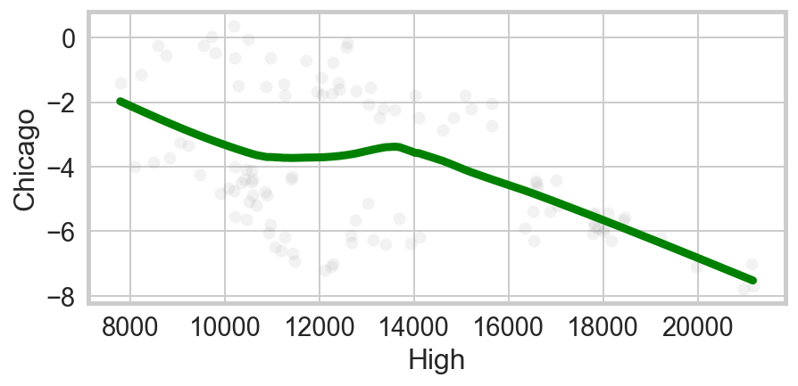

```python
m = pd.Series(name = "Chicago", data = model.resid + test3["High"] * model.params["High"])
sns.regplot(x = test3["High"], y = m, lowess = True,
            scatter_kws = {"alpha" : 0.1, "color" : "grey"}, line_kws = {"color" : "green"});
```

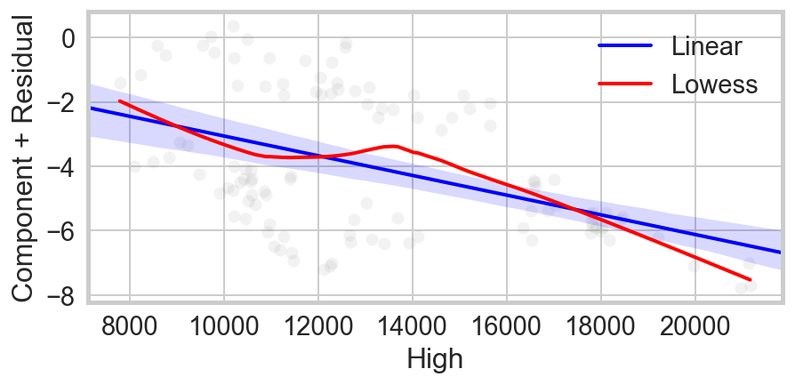

```python
f = pd.Series(name = "Component + Residual", data = model.resid + test3["High"] * model.params["High"])
ax = sns.regplot(x = test3["High"], y = f, scatter = True, fit_reg = False,
            scatter_kws = {"alpha" : 0.1, "color" : "grey"})
sns.regplot(x = test3["High"], y = f, scatter = False,
            lowess = False, robust = True, label = "Linear",
            scatter_kws = {"alpha" : 0.1, "color" : "grey"}, line_kws = {"color" : "blue", "linewidth" : 2})
sns.regplot(x = test3["High"], y = f, scatter = False,
            lowess = True, label = "Lowess",
            scatter_kws = {"alpha" : 0}, line_kws = {"color" : "red", "linewidth" : 2}, ax = ax);

ax.legend()
```

#### We plot the relationship between unemployment and Low stock price

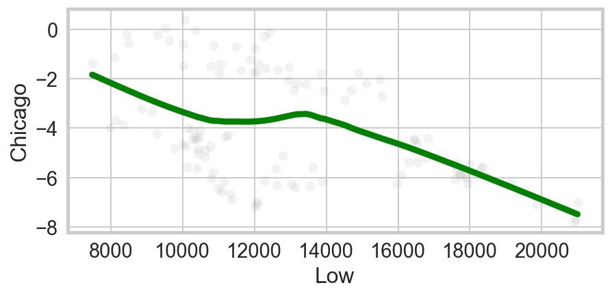

```python
m = pd.Series(name = "Chicago", data = model.resid + test3["Low"] * model.params["Low"])
sns.regplot(x = test3["Low"], y = m, lowess = True,
            scatter_kws = {"alpha" : 0.1, "color" : "grey"}, line_kws = {"color" : "green"});
```

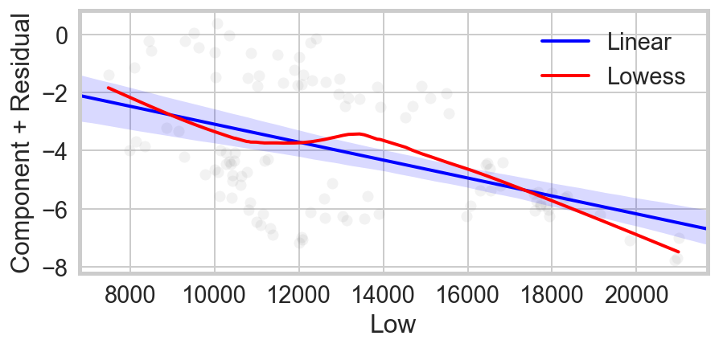

```python
f = pd.Series(name = "Component + Residual", data = model.resid + test3["Low"] * model.params["Low"])
ax = sns.regplot(x = test3["Low"], y = f, scatter = True, fit_reg = False,
            scatter_kws = {"alpha" : 0.1, "color" : "grey"})
sns.regplot(x = test3["Low"], y = f, scatter = False,
            lowess = False, robust = True, label = "Linear",
            scatter_kws = {"alpha" : 0.1, "color" : "grey"}, line_kws = {"color" : "blue", "linewidth" : 2})
sns.regplot(x = test3["Low"], y = f, scatter = False,
            lowess = True, label = "Lowess",
            scatter_kws = {"alpha" : 0}, line_kws = {"color" : "red", "linewidth" : 2}, ax = ax);

ax.legend()
```